# What a structure prediction confidence score is worth

The full analysis, read from the tables in results/

**show the code that produced this**

```python
import os
import sys
from pathlib import Path

import pandas as pd

# This report reads only files in results/ and figures/. It recomputes nothing,
# so a number here and the same number in the README come from one file.
#
# project.conf is located by walking up from the working directory rather than
# taken as a parameter, because the renderer works from the document's own
# directory in some versions and from the project root in others, and a report
# that cannot find its own config depending on how it was invoked is not
# reproducible. CSC_CONFIG overrides.
candidates = []
if os.environ.get("CSC_CONFIG"):
    candidates.append(Path(os.environ["CSC_CONFIG"]))
here = Path.cwd().resolve()
candidates += [here / "project.conf"] + [p / "project.conf" for p in here.parents]
conf_file = next((c for c in candidates if c.is_file()), None)
if conf_file is None:
    raise SystemExit("project.conf not found; run scripts/00_configure.sh first")

sys.path.insert(0, str((conf_file.parent / "scripts").resolve()))
import lib_csc as L

conf = L.load_conf(conf_file)
RESULTS = Path(conf["RESULTS_DIR"])
FIGURES = Path(conf["FIGURES_DIR"])
LOGS = Path(conf["LOG_DIR"])
PLDDT_HIGH = L.conf_float(conf, "PLDDT_HIGH", 90.0)
LDDT_TRUST = L.conf_float(conf, "LDDT_TRUST", 0.7)


def load(rel, root=RESULTS):
    p = Path(root) / rel
    if not p.is_file():
        return None
    try:
        df = pd.read_csv(p, sep="\t")
    except Exception:
        return None
    return df if len(df) else None


def show(df, msg="This table has not been produced yet."):
    if df is None:
        print(msg)
        return None
    return df
```

## What this measures

Two questions, and the second is the one that decides whether the first matters.

How well does a confidence value predict the accuracy it claims to predict. The confidence head of a structure prediction model is trained to predict the model’s own local distance difference score against the true structure, on a scale of 0 to 100. It does not predict deviation after superposition, it does not predict whether the fold is right, and it says nothing at all about how two confidently predicted pieces sit relative to each other. So it is compared here against the quantity it was trained on, computed the way that quantity is defined, and the comparison is shown as a scatter rather than summarised as a correlation.

And whether a confident structure is a physically possible one. A previous stage of this work found that a docked pose can sit within 1.4 Angstrom of the experimental one and still be chemically impossible, because nothing in a docking score enforces chemistry. The same question is asked here of predicted backbones and side chains, and the only figure called success is the one that requires both accuracy and validity.

## The machine, measured rather than assumed

**show the code that produced this**

```python
curve = load("environment/memory_curve.tsv")
show(curve, "The calibration has not run yet.")
```

|  | target_id | sequence_length | peak_rss_mb | elapsed_s | arm | recorded |
| --- | --- | --- | --- | --- | --- | --- |
| 0 | 10UV_1 | 140 | 3007 | 166.94 | af2_nomsa | 2026-09-25T20:05:05+08:00 |
| 1 | 10AF_1 | 179 | 2864 | 257.86 | af2_nomsa | 2026-09-25T20:09:23+08:00 |
| 2 | 10QV_1 | 294 | 3347 | 730.54 | af2_nomsa | 2026-09-25T20:21:34+08:00 |

**show the code that produced this**

```python
versions = load("environment/versions.tsv")
show(versions, "The environment has not been recorded yet.")
```

|  | tool | version | source | detail | recorded |
| --- | --- | --- | --- | --- | --- |
| 0 | python | 3.12.14 | conda/csc_analysis | h5f976f7_3_cpython | 2026-09-25T19:39:07+08:00 |
| 1 | gemmi | 0.7.5 | conda/csc_analysis | py312h27102bb_0 | 2026-09-25T19:39:07+08:00 |
| 2 | biopython | 1.88 | conda/csc_analysis | py312h5cc1888_1 | 2026-09-25T19:39:07+08:00 |
| 3 | numpy | 2.5.3 | conda/csc_analysis | py312he827f4e_0 | 2026-09-25T19:39:07+08:00 |
| 4 | scipy | 1.18.1 | conda/csc_analysis | py312h106c528_1 | 2026-09-25T19:39:07+08:00 |
| 5 | pandas | 3.0.6 | conda/csc_analysis | np2py312h91ec553_0 | 2026-09-25T19:39:07+08:00 |
| 6 | matplotlib-base | 3.11.2 | conda/csc_analysis | py312hfe9aac7_1 | 2026-09-25T19:39:07+08:00 |
| 7 | seaborn | 0.13.2 | conda/csc_analysis | hd8ed1ab_3 | 2026-09-25T19:39:07+08:00 |
| 8 | statsmodels | 0.15.0 | conda/csc_analysis | np2py312h32d774f_2 | 2026-09-25T19:39:07+08:00 |
| 9 | requests | 2.34.2 | conda/csc_analysis | pyhcf101f3_0 | 2026-09-25T19:39:07+08:00 |
| 10 | quarto | 1.9.38 | conda/csc_analysis | hd55b112_0 | 2026-09-25T19:39:07+08:00 |
| 11 | shellcheck | 0.11.0 | conda/csc_analysis | ha770c72_1 | 2026-09-25T19:39:07+08:00 |
| 12 | python | 3.12.14 | conda/csc_ost | h5f976f7_3_cpython | 2026-09-25T19:39:08+08:00 |
| 13 | openstructure | 2.12.0 | conda/csc_ost | py312heaa34e3_0 | 2026-09-25T19:39:08+08:00 |
| 14 | usalign | 20241201 | conda/csc_ost | h503566f_0 | 2026-09-25T19:39:08+08:00 |
| 15 | numpy | 2.5.3 | conda/csc_ost | py312he827f4e_0 | 2026-09-25T19:39:08+08:00 |
| 16 | colabfold | 1.6.3 | pip/csc_colabfold | NaN | 2026-09-25T19:39:09+08:00 |
| 17 | alphafold-colabfold | 2.3.20 | pip/csc_colabfold | NaN | 2026-09-25T19:39:09+08:00 |
| 18 | jax | 0.10.2 | pip/csc_colabfold | NaN | 2026-09-25T19:39:09+08:00 |
| 19 | jaxlib | 0.10.2 | pip/csc_colabfold | NaN | 2026-09-25T19:39:09+08:00 |
| 20 | numpy | 2.5.3 | pip/csc_colabfold | NaN | 2026-09-25T19:39:09+08:00 |
| 21 | biopython | 1.85 | pip/csc_colabfold | NaN | 2026-09-25T19:39:09+08:00 |
| 22 | dm-haiku | 0.0.17 | pip/csc_colabfold | NaN | 2026-09-25T19:39:09+08:00 |
| 23 | colabfold-binaries | 0.1.0 | pip/csc_colabfold | NaN | 2026-09-25T19:39:09+08:00 |
| 24 | colabfold-legacy-kernels | 0.2.0 | pip/csc_colabfold | NaN | 2026-09-25T19:39:09+08:00 |
| 25 | absl-py | 1.4.0 | pip/csc_colabfold | NaN | 2026-09-25T19:39:09+08:00 |
| 26 | boltz | 2.2.1 | pip/csc_boltz | NaN | 2026-09-25T19:39:09+08:00 |
| 27 | torch | 2.14.0+cpu | pip/csc_boltz | NaN | 2026-09-25T19:39:09+08:00 |
| 28 | numpy | 1.26.4 | pip/csc_boltz | NaN | 2026-09-25T19:39:09+08:00 |
| 29 | pytorch-lightning | 2.5.0 | pip/csc_boltz | NaN | 2026-09-25T19:39:09+08:00 |
| 30 | rdkit | 2026.3.6 | pip/csc_boltz | NaN | 2026-09-25T19:39:09+08:00 |
| 31 | fairscale | 0.4.13 | pip/csc_boltz | NaN | 2026-09-25T19:39:09+08:00 |
| 32 | torchmetrics | 1.9.0 | pip/csc_boltz | NaN | 2026-09-25T19:39:09+08:00 |
| 33 | boltz_commit | b1ebfc46ecf57f5414e0d1a6f9027bbb122c53bc | git | development branch; the release of this versio... | 2026-09-25T19:39:09+08:00 |
| 34 | boltz_cpu_precision_fix | present | source | autocast disabled for the active device in bol... | 2026-09-25T19:39:09+08:00 |
| 35 | boltz_trunk_precision | precision=32 if model == "boltz1" else "bf16-m... | source | the merged fix covers the diffusion and affini... | 2026-09-25T19:39:09+08:00 |
| 36 | ost_compound_lib | 2026-08-16 | openstructure | built with OpenStructure 2.12.0 | 2026-09-25T19:39:09+08:00 |
| 37 | conda | 26.7.2 | base | conda | 2026-09-25T19:39:10+08:00 |
| 38 | kernel | 6.18.33.2-microsoft-standard-WSL2 | host | Linux x86_64 | 2026-09-25T19:39:10+08:00 |
| 39 | glibc | 2.43 | host | wheel compatibility floor | 2026-09-25T19:39:10+08:00 |
| 40 | cpu_flags | avx2 | host | the prebuilt template search binaries require ... | 2026-09-25T19:39:10+08:00 |
| 41 | gpu | none | 00_configure.sh | every timing in this repository is a CPU timing | 2026-09-25T19:39:10+08:00 |

Every timing in this report is a processor timing. The accelerator probe is recorded in `results/environment/accelerator.tsv` and what it found is in the table above.

## The held-out set, and what a date filter is worth

**show the code that produced this**

```python
summary = load("holdout_set_summary.tsv")
show(summary, "The set has not been built yet.")
```

|  | key | value | note |
| --- | --- | --- | --- |
| 0 | per_model_cutoffs | alphafold2_ptm=2018-04-30; boltz2=2023-06-01 | read from config/model_cutoffs.tsv with the so... |
| 1 | common_cutoff | 2023-06-01 | the latest per-model cutoff, so one set is out... |
| 2 | earliest_cutoff | 2018-04-30 | a per-model set for the older model could have... |
| 3 | entities_passing_filters | 7189 | before clustering |
| 4 | clusters_at_identity | 1391 | at 30 per cent identity, one representative each |
| 5 | candidates_examined | 320 | cluster representatives whose records were fet... |
| 6 | release_date_only_clusters | 1682 | what the same filter admits when the depositio... |
| 7 | release_date_only_extra | 291 | entries a release-date split would have admitt... |
| 8 | targets_after_sequence_checks | 313 | before the memory ceiling and the time budget |
| 9 | excluded_for_length | 0 | longer than 300 residues, which this machine c... |
| 10 | excluded_for_time | 163 | beyond what the wall-clock budget allows; the ... |
| 11 | targets_final | 150 | the set every arm is run on |
| 12 | identity_none | 30 | no pre-cutoff relative found by sequence search |
| 13 | identity_under_30 | 3 | a pre-cutoff relative below 30 per cent identity |
| 14 | identity_30_to_70 | 38 | 30 to 70 per cent |
| 15 | identity_70_to_95 | 12 | 70 to 95 per cent |
| 16 | identity_95_to_100 | 67 | 95 per cent or better, which is the same prote... |
| 17 | identity_exactly_100 | 56 | an identical sequence was already in the archi... |
| 18 | docking_subset | 15 | targets with a ligand passing every quality fi... |
| 19 | ligand_instances_considered | 529 | before the ligand filters |
| 20 | search_schema_version | 1.59.0 | the RCSB search schema this set was built against |
| 21 | query_date | 2026-09-25 | clusters are recomputed weekly, so this date m... |
| 22 | api_requests | 102 | requests made; the rest came from the local cache |
| 23 | api_cached | 847 | requests served from the local cache |

A date filter selects entries the models cannot have been trained on. It does not select proteins they have never seen. Most newly released structures are new determinations of something already in the archive, and the identity bands in the table above are how much of that there is in this set. Those targets are kept and flagged rather than removed: a target with a close pre-cutoff relative is exactly the case worth measuring, and dropping it would remove the evidence instead of reporting it.

## Calibration

**show the code that produced this**

```python
calib = load("calibration.tsv")
show(calib, "The analysis has not run yet.")
```

|  | arm | n_residues | n_targets | pearson_r | spearman_rho | expected_calibration_error | calibration_bins | mean_confidence | mean_measured_lddt_ca | n_residues_above_high_band | n_of_those_below_trust | fraction_above_band_below_trust | fraction_ci_low | fraction_ci_high | high_band | trust_line | recorded |
| --- | --- | --- | --- | --- | --- | --- | --- | --- | --- | --- | --- | --- | --- | --- | --- | --- | --- |
| 0 | af2_msa_notmpl | 3213 | 30 | 0.7346 | 0.5977 | 0.0141 | 10 | 0.9089 | 0.9021 | 2463 | 34 | 0.0138 | 0.0066 | 0.0219 | 90.0 | 0.7 | 2026-09-26T19:30:54+08:00 |
| 1 | af2_msa_tmpl | 1160 | 11 | 0.5120 | 0.5362 | 0.0297 | 10 | 0.9210 | 0.9036 | 874 | 23 | 0.0263 | 0.0086 | 0.0445 | 90.0 | 0.7 | 2026-09-26T19:30:54+08:00 |
| 2 | af2_nomsa | 18801 | 149 | 0.7983 | 0.7104 | 0.0245 | 10 | 0.4518 | 0.4280 | 663 | 1 | 0.0015 | 0.0000 | 0.0055 | 90.0 | 0.7 | 2026-09-26T19:30:55+08:00 |

**show the code that produced this**

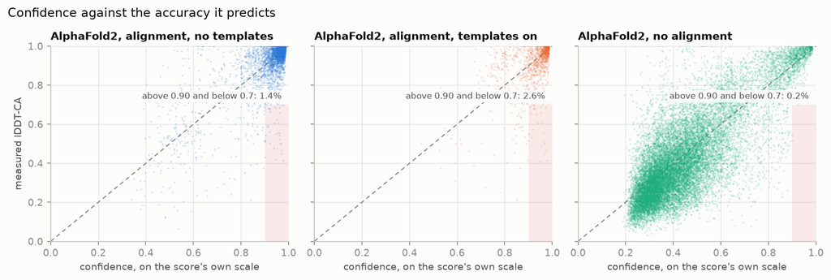

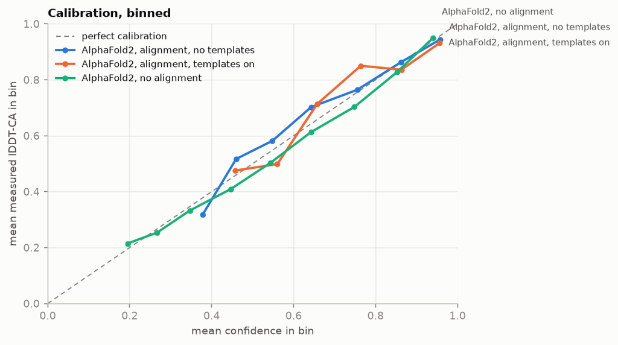

```python
from IPython.display import Image, display

for name in ("fig1_calibration_scatter.png", "fig2_calibration_curve.png"):
    p = FIGURES / name
    if p.is_file():
        display(Image(filename=str(p)))
```

**show the code that produced this**

```python
show(load("calibration_bins.tsv"), "No binned calibration yet.")
```

|  | arm | bin_low | bin_high | n | mean_confidence | mean_measured | gap | recorded |
| --- | --- | --- | --- | --- | --- | --- | --- | --- |
| 0 | af2_msa_notmpl | 0.0 | 0.1 | 0 | NaN | NaN | NaN | 2026-09-26T19:30:54+08:00 |
| 1 | af2_msa_notmpl | 0.1 | 0.2 | 0 | NaN | NaN | NaN | 2026-09-26T19:30:54+08:00 |
| 2 | af2_msa_notmpl | 0.2 | 0.3 | 0 | NaN | NaN | NaN | 2026-09-26T19:30:54+08:00 |
| 3 | af2_msa_notmpl | 0.3 | 0.4 | 12 | 0.3784 | 0.3187 | 0.0598 | 2026-09-26T19:30:54+08:00 |
| 4 | af2_msa_notmpl | 0.4 | 0.5 | 48 | 0.4597 | 0.5168 | -0.0571 | 2026-09-26T19:30:54+08:00 |
| 5 | af2_msa_notmpl | 0.5 | 0.6 | 102 | 0.5481 | 0.5817 | -0.0336 | 2026-09-26T19:30:54+08:00 |
| 6 | af2_msa_notmpl | 0.6 | 0.7 | 75 | 0.6429 | 0.7025 | -0.0597 | 2026-09-26T19:30:54+08:00 |
| 7 | af2_msa_notmpl | 0.7 | 0.8 | 92 | 0.7553 | 0.7642 | -0.0089 | 2026-09-26T19:30:54+08:00 |
| 8 | af2_msa_notmpl | 0.8 | 0.9 | 421 | 0.8626 | 0.8635 | -0.0009 | 2026-09-26T19:30:54+08:00 |
| 9 | af2_msa_notmpl | 0.9 | 1.0 | 2463 | 0.9569 | 0.9436 | 0.0133 | 2026-09-26T19:30:54+08:00 |
| 10 | af2_msa_tmpl | 0.0 | 0.1 | 0 | NaN | NaN | NaN | 2026-09-26T19:30:54+08:00 |
| 11 | af2_msa_tmpl | 0.1 | 0.2 | 0 | NaN | NaN | NaN | 2026-09-26T19:30:54+08:00 |
| 12 | af2_msa_tmpl | 0.2 | 0.3 | 0 | NaN | NaN | NaN | 2026-09-26T19:30:54+08:00 |
| 13 | af2_msa_tmpl | 0.3 | 0.4 | 0 | NaN | NaN | NaN | 2026-09-26T19:30:54+08:00 |
| 14 | af2_msa_tmpl | 0.4 | 0.5 | 2 | 0.4577 | 0.4755 | -0.0179 | 2026-09-26T19:30:54+08:00 |
| 15 | af2_msa_tmpl | 0.5 | 0.6 | 9 | 0.5602 | 0.4986 | 0.0617 | 2026-09-26T19:30:54+08:00 |
| 16 | af2_msa_tmpl | 0.6 | 0.7 | 16 | 0.6577 | 0.7139 | -0.0562 | 2026-09-26T19:30:54+08:00 |
| 17 | af2_msa_tmpl | 0.7 | 0.8 | 72 | 0.7639 | 0.8502 | -0.0863 | 2026-09-26T19:30:54+08:00 |
| 18 | af2_msa_tmpl | 0.8 | 0.9 | 187 | 0.8627 | 0.8360 | 0.0266 | 2026-09-26T19:30:54+08:00 |
| 19 | af2_msa_tmpl | 0.9 | 1.0 | 874 | 0.9560 | 0.9311 | 0.0249 | 2026-09-26T19:30:54+08:00 |
| 20 | af2_nomsa | 0.0 | 0.1 | 0 | NaN | NaN | NaN | 2026-09-26T19:30:55+08:00 |
| 21 | af2_nomsa | 0.1 | 0.2 | 10 | 0.1947 | 0.2146 | -0.0199 | 2026-09-26T19:30:55+08:00 |
| 22 | af2_nomsa | 0.2 | 0.3 | 3363 | 0.2670 | 0.2537 | 0.0132 | 2026-09-26T19:30:55+08:00 |
| 23 | af2_nomsa | 0.3 | 0.4 | 5804 | 0.3469 | 0.3326 | 0.0143 | 2026-09-26T19:30:55+08:00 |
| 24 | af2_nomsa | 0.4 | 0.5 | 4138 | 0.4467 | 0.4094 | 0.0373 | 2026-09-26T19:30:55+08:00 |
| 25 | af2_nomsa | 0.5 | 0.6 | 2205 | 0.5428 | 0.5023 | 0.0405 | 2026-09-26T19:30:55+08:00 |
| 26 | af2_nomsa | 0.6 | 0.7 | 1218 | 0.6425 | 0.6129 | 0.0295 | 2026-09-26T19:30:55+08:00 |
| 27 | af2_nomsa | 0.7 | 0.8 | 605 | 0.7484 | 0.7031 | 0.0453 | 2026-09-26T19:30:55+08:00 |
| 28 | af2_nomsa | 0.8 | 0.9 | 795 | 0.8521 | 0.8272 | 0.0249 | 2026-09-26T19:30:55+08:00 |
| 29 | af2_nomsa | 0.9 | 1.0 | 663 | 0.9394 | 0.9488 | -0.0095 | 2026-09-26T19:30:55+08:00 |

## Where to stop trusting a confident region

**show the code that produced this**

```python
show(load("threshold_sweep.tsv"), "No threshold sweep yet.")
```

|  | arm | band | n_residues_at_or_above | n_below_trust | fraction_below_trust | trust_line | recorded |
| --- | --- | --- | --- | --- | --- | --- | --- |
| 0 | af2_msa_notmpl | 50 | 3153 | 212 | 0.0672 | 0.7 | 2026-09-26T19:30:55+08:00 |
| 1 | af2_msa_notmpl | 55 | 3102 | 171 | 0.0551 | 0.7 | 2026-09-26T19:30:55+08:00 |
| 2 | af2_msa_notmpl | 60 | 3051 | 136 | 0.0446 | 0.7 | 2026-09-26T19:30:55+08:00 |
| 3 | af2_msa_notmpl | 65 | 3005 | 107 | 0.0356 | 0.7 | 2026-09-26T19:30:55+08:00 |
| 4 | af2_msa_notmpl | 70 | 2976 | 98 | 0.0329 | 0.7 | 2026-09-26T19:30:55+08:00 |
| 5 | af2_msa_notmpl | 75 | 2938 | 86 | 0.0293 | 0.7 | 2026-09-26T19:30:55+08:00 |
| 6 | af2_msa_notmpl | 80 | 2884 | 74 | 0.0257 | 0.7 | 2026-09-26T19:30:55+08:00 |
| 7 | af2_msa_notmpl | 85 | 2755 | 55 | 0.0200 | 0.7 | 2026-09-26T19:30:55+08:00 |
| 8 | af2_msa_notmpl | 90 | 2463 | 34 | 0.0138 | 0.7 | 2026-09-26T19:30:55+08:00 |
| 9 | af2_msa_notmpl | 95 | 1665 | 15 | 0.0090 | 0.7 | 2026-09-26T19:30:55+08:00 |
| 10 | af2_msa_tmpl | 50 | 1158 | 74 | 0.0639 | 0.7 | 2026-09-26T19:30:55+08:00 |
| 11 | af2_msa_tmpl | 55 | 1154 | 71 | 0.0615 | 0.7 | 2026-09-26T19:30:55+08:00 |
| 12 | af2_msa_tmpl | 60 | 1149 | 66 | 0.0574 | 0.7 | 2026-09-26T19:30:55+08:00 |
| 13 | af2_msa_tmpl | 65 | 1144 | 62 | 0.0542 | 0.7 | 2026-09-26T19:30:55+08:00 |
| 14 | af2_msa_tmpl | 70 | 1133 | 58 | 0.0512 | 0.7 | 2026-09-26T19:30:55+08:00 |
| 15 | af2_msa_tmpl | 75 | 1111 | 53 | 0.0477 | 0.7 | 2026-09-26T19:30:55+08:00 |
| 16 | af2_msa_tmpl | 80 | 1061 | 50 | 0.0471 | 0.7 | 2026-09-26T19:30:55+08:00 |
| 17 | af2_msa_tmpl | 85 | 1000 | 41 | 0.0410 | 0.7 | 2026-09-26T19:30:55+08:00 |
| 18 | af2_msa_tmpl | 90 | 874 | 23 | 0.0263 | 0.7 | 2026-09-26T19:30:55+08:00 |
| 19 | af2_msa_tmpl | 95 | 586 | 11 | 0.0188 | 0.7 | 2026-09-26T19:30:55+08:00 |
| 20 | af2_nomsa | 50 | 5486 | 3132 | 0.5709 | 0.7 | 2026-09-26T19:30:55+08:00 |
| 21 | af2_nomsa | 55 | 4146 | 1880 | 0.4534 | 0.7 | 2026-09-26T19:30:55+08:00 |
| 22 | af2_nomsa | 60 | 3281 | 1157 | 0.3526 | 0.7 | 2026-09-26T19:30:55+08:00 |
| 23 | af2_nomsa | 65 | 2534 | 656 | 0.2589 | 0.7 | 2026-09-26T19:30:55+08:00 |
| 24 | af2_nomsa | 70 | 2063 | 362 | 0.1755 | 0.7 | 2026-09-26T19:30:55+08:00 |
| 25 | af2_nomsa | 75 | 1745 | 222 | 0.1272 | 0.7 | 2026-09-26T19:30:55+08:00 |
| 26 | af2_nomsa | 80 | 1458 | 116 | 0.0796 | 0.7 | 2026-09-26T19:30:55+08:00 |
| 27 | af2_nomsa | 85 | 1085 | 52 | 0.0479 | 0.7 | 2026-09-26T19:30:55+08:00 |
| 28 | af2_nomsa | 90 | 663 | 1 | 0.0015 | 0.7 | 2026-09-26T19:30:55+08:00 |
| 29 | af2_nomsa | 95 | 234 | 0 | 0.0000 | 0.7 | 2026-09-26T19:30:55+08:00 |

**show the code that produced this**

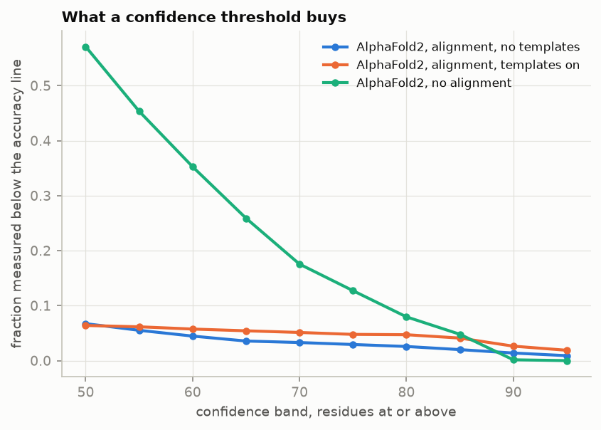

```python
p = FIGURES / "fig3_threshold_sweep.png"
if p.is_file():
    display(Image(filename=str(p)))
```

The sweep is the answer rather than any single value in it. A threshold read off this table is arbitrary unless the sweep shows a knee, and the README says which it is.

## Accuracy and physical validity per arm

**show the code that produced this**

```python
show(load("arm_comparison.tsv"), "No arm comparison yet.")
```

|  | arm | n_targets | lddt_ca_median | lddt_ca_q1 | lddt_ca_q3 | tm_score_median | n_geometry_checked | n_passing_geometry | fraction_passing_geometry | n_passing_geometry_strict | fraction_passing_geometry_strict | n_accurate_and_valid | fraction_accurate_and_valid | accuracy_line | recorded |
| --- | --- | --- | --- | --- | --- | --- | --- | --- | --- | --- | --- | --- | --- | --- | --- |
| 0 | af2_msa_notmpl | 30 | 0.9250 | 0.8955 | 0.9570 | 0.9305 | 30 | 7 | 0.2333 | 4 | 0.1333 | 7 | 0.2333 | 0.7 | 2026-09-26T19:30:55+08:00 |
| 1 | af2_msa_tmpl | 11 | 0.9080 | 0.9030 | 0.9285 | 0.9360 | 11 | 4 | 0.3636 | 3 | 0.2727 | 4 | 0.3636 | 0.7 | 2026-09-26T19:30:55+08:00 |
| 2 | af2_nomsa | 149 | 0.3780 | 0.3100 | 0.5000 | 0.4020 | 149 | 3 | 0.0201 | 0 | 0.0000 | 3 | 0.0201 | 0.7 | 2026-09-26T19:30:55+08:00 |
| 3 | null_template | 120 | 0.8825 | 0.6800 | 0.9612 | 0.9115 | 120 | 103 | 0.8583 | 59 | 0.4917 | 78 | 0.6500 | 0.7 | 2026-09-26T19:30:55+08:00 |
| 4 | null_unrelated | 150 | 0.0160 | 0.0000 | 0.0607 | 0.3030 | 150 | 132 | 0.8800 | 59 | 0.3933 | 0 | 0.0000 | 0.7 | 2026-09-26T19:30:55+08:00 |

The table below is the comparison that can be read that way: for each pair of arms, the difference per target over the targets both of them predicted. The interval resamples targets rather than residues. The count of shared targets is the number that decides what each comparison supports.

**show the code that produced this**

```python
show(load("arm_pairs.tsv"), "No paired arm comparison yet.")
```

|  | arm_a | arm_b | n_shared_targets | median_lddt_ca_a | median_lddt_ca_b | median_paired_difference | ci_low | ci_high | n_targets_b_higher | note | recorded |
| --- | --- | --- | --- | --- | --- | --- | --- | --- | --- | --- | --- |
| 0 | af2_msa_notmpl | af2_msa_tmpl | 11 | 0.9040 | 0.9080 | 0.0020 | 0.000 | 0.0080 | 6 | b minus a, per target, over the targets both a... | 2026-09-26T19:30:55+08:00 |
| 1 | af2_msa_notmpl | af2_nomsa | 30 | 0.9250 | 0.4425 | -0.4760 | -0.546 | -0.3105 | 0 | b minus a, per target, over the targets both a... | 2026-09-26T19:30:55+08:00 |
| 2 | af2_msa_notmpl | null_template | 19 | 0.9220 | 0.7930 | -0.1090 | -0.185 | -0.0320 | 2 | b minus a, per target, over the targets both a... | 2026-09-26T19:30:55+08:00 |
| 3 | af2_msa_notmpl | null_unrelated | 30 | 0.9250 | 0.0125 | -0.8940 | -0.912 | -0.8435 | 0 | b minus a, per target, over the targets both a... | 2026-09-26T19:30:55+08:00 |
| 4 | af2_msa_tmpl | af2_nomsa | 11 | 0.9080 | 0.4580 | -0.4580 | -0.604 | -0.0210 | 0 | b minus a, per target, over the targets both a... | 2026-09-26T19:30:55+08:00 |
| 5 | af2_msa_tmpl | null_template | 7 | 0.9080 | 0.7150 | -0.1350 | -0.579 | -0.0450 | 0 | b minus a, per target, over the targets both a... | 2026-09-26T19:30:55+08:00 |
| 6 | af2_msa_tmpl | null_unrelated | 11 | 0.9080 | 0.0180 | -0.8940 | -0.919 | -0.8320 | 0 | b minus a, per target, over the targets both a... | 2026-09-26T19:30:55+08:00 |
| 7 | af2_nomsa | null_template | 119 | 0.3630 | 0.8810 | 0.4410 | 0.403 | 0.5240 | 98 | b minus a, per target, over the targets both a... | 2026-09-26T19:30:55+08:00 |
| 8 | af2_nomsa | null_unrelated | 149 | 0.3780 | 0.0160 | -0.3400 | -0.372 | -0.3190 | 1 | b minus a, per target, over the targets both a... | 2026-09-26T19:30:55+08:00 |
| 9 | null_template | null_unrelated | 120 | 0.8825 | 0.0160 | -0.7885 | -0.842 | -0.7515 | 3 | b minus a, per target, over the targets both a... | 2026-09-26T19:30:55+08:00 |

**show the code that produced this**

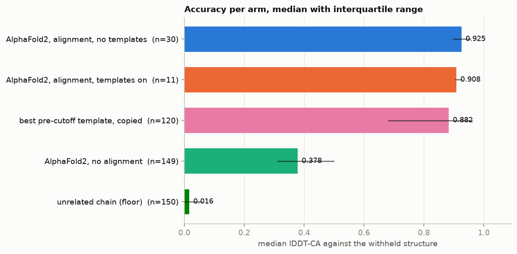

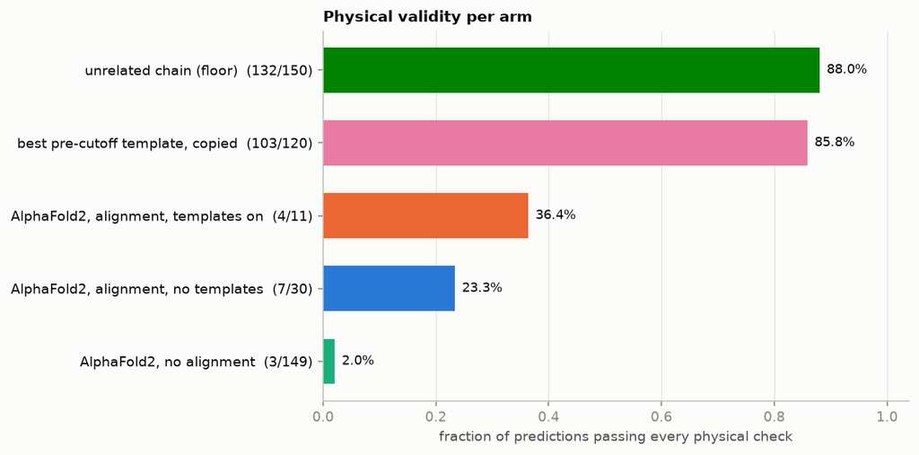

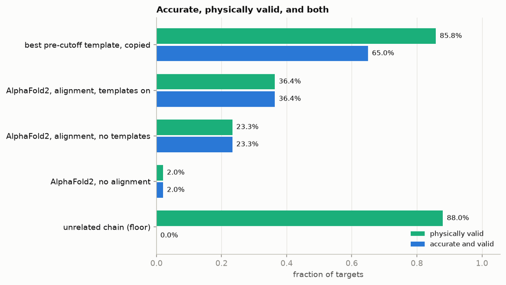

```python
for name in ("fig4_arm_accuracy.png", "fig5_geometry_pass.png",
             "fig6_accuracy_and_validity.png"):
    p = FIGURES / name
    if p.is_file():
        display(Image(filename=str(p)))
```

**show the code that produced this**

```python
show(load("geometry_checks.tsv"), "No geometry checks yet.")
```

|  | target_id | arm | model | status | reason | n_residues | tolerance_used | bad_bonds | bad_angles | bad_bonds_strict | ... | rama_outliers | rama_allowed | rama_favoured | rama_scored | rama_outlier_fraction | passes_all | failed_checks | within_deposited_range | over_threshold_checks | recorded |
| --- | --- | --- | --- | --- | --- | --- | --- | --- | --- | --- | --- | --- | --- | --- | --- | --- | --- | --- | --- | --- | --- |
| 0 | 27WO_1 | af2_nomsa | alphafold2_ptm | ok | NaN | 81 | 12.0 | 0 | 5 | 22 | ... | 8 | 7 | 64 | 79 | 0.1013 | 0 | bond angles: 5; non-bonded clashes: 2; twisted... | 0 | bad_angles; clashes | 2026-09-26T16:13:35+08:00 |
| 1 | 27AH_1 | af2_nomsa | alphafold2_ptm | ok | NaN | 82 | 12.0 | 0 | 0 | 2 | ... | 1 | 2 | 77 | 80 | 0.0125 | 0 | Ramachandran outliers: 1 | 1 | NaN | 2026-09-26T16:13:37+08:00 |
| 2 | 8PQM_1 | af2_nomsa | alphafold2_ptm | ok | NaN | 82 | 12.0 | 0 | 1 | 8 | ... | 0 | 4 | 76 | 80 | 0.0000 | 0 | bond angles: 1 | 0 | bad_angles | 2026-09-26T16:13:39+08:00 |
| 3 | 36MB_1 | af2_nomsa | alphafold2_ptm | ok | NaN | 83 | 12.0 | 0 | 1 | 11 | ... | 0 | 0 | 81 | 81 | 0.0000 | 0 | bond angles: 1 | 0 | bad_angles | 2026-09-26T16:13:40+08:00 |
| 4 | 8PRR_1 | af2_nomsa | alphafold2_ptm | ok | NaN | 84 | 12.0 | 1 | 5 | 12 | ... | 8 | 5 | 69 | 82 | 0.0976 | 0 | bond lengths: 1; bond angles: 5; Ramachandran ... | 0 | bad_angles | 2026-09-26T16:13:41+08:00 |
| ... | ... | ... | ... | ... | ... | ... | ... | ... | ... | ... | ... | ... | ... | ... | ... | ... | ... | ... | ... | ... | ... |
| 455 | 8PR6_1 | af2_msa_tmpl | alphafold2_ptm | ok | NaN | 85 | 12.0 | 0 | 1 | 6 | ... | 5 | 2 | 76 | 83 | 0.0602 | 0 | bond angles: 1; twisted peptide bonds: 6; Rama... | 0 | bad_angles; twisted_peptides | 2026-09-26T17:49:31+08:00 |
| 456 | 8PWC_1 | af2_msa_tmpl | alphafold2_ptm | ok | NaN | 110 | 12.0 | 0 | 6 | 10 | ... | 5 | 9 | 94 | 108 | 0.0463 | 0 | bond angles: 6; twisted peptide bonds: 6; Rama... | 0 | bad_angles; twisted_peptides | 2026-09-26T18:24:58+08:00 |
| 457 | 8JN0_1 | af2_msa_tmpl | alphafold2_ptm | ok | NaN | 89 | 12.0 | 0 | 0 | 5 | ... | 0 | 1 | 86 | 87 | 0.0000 | 1 | NaN | 1 | NaN | 2026-09-26T18:24:59+08:00 |
| 458 | 36IQ_1 | af2_msa_tmpl | alphafold2_ptm | ok | NaN | 98 | 12.0 | 0 | 0 | 14 | ... | 0 | 1 | 95 | 96 | 0.0000 | 1 | NaN | 1 | NaN | 2026-09-26T18:25:00+08:00 |
| 459 | 10XE_1 | af2_msa_tmpl | alphafold2_ptm | ok | NaN | 91 | 12.0 | 0 | 0 | 3 | ... | 0 | 0 | 89 | 89 | 0.0000 | 1 | NaN | 1 | NaN | 2026-09-26T18:25:01+08:00 |

460 rows × 26 columns

## Docking into a predicted receptor

**show the code that produced this**

```python
show(load("docking_handoff.tsv"), "The docking handoff has not run yet.")
```

|  | arm | method | n_attempted | n_scored | n_assessed | n_rmsd_within_2a | rate_rmsd_within_2a | n_success | rate_success | ci_low | ci_high | median_top1_rmsd | note | recorded |
| --- | --- | --- | --- | --- | --- | --- | --- | --- | --- | --- | --- | --- | --- | --- |
| 0 | predicted/A0_null | vina | 13 | 12 | 12 | 0 | 0.0000 | 0 | 0.0000 | 0.0000 | 0.2425 | 6.745 | success requires the pose within 2 Angstrom an... | 2026-09-26T19:30:21+08:00 |
| 1 | predicted/A2_genconf_refbox | vina | 13 | 11 | 11 | 1 | 0.0909 | 1 | 0.0909 | 0.0162 | 0.3774 | 7.904 | success requires the pose within 2 Angstrom an... | 2026-09-26T19:30:21+08:00 |
| 2 | predicted/A2_genconf_refbox | vinardo | 13 | 9 | 9 | 1 | 0.1111 | 1 | 0.1111 | 0.0199 | 0.4350 | 7.713 | success requires the pose within 2 Angstrom an... | 2026-09-26T19:30:21+08:00 |
| 3 | crystal/A0_null | vina | 13 | 12 | 12 | 0 | 0.0000 | 0 | 0.0000 | 0.0000 | 0.2425 | 6.745 | success requires the pose within 2 Angstrom an... | 2026-09-26T19:30:21+08:00 |
| 4 | crystal/A2_genconf_refbox | vina | 13 | 11 | 11 | 4 | 0.3636 | 4 | 0.3636 | 0.1517 | 0.6462 | 6.332 | success requires the pose within 2 Angstrom an... | 2026-09-26T19:30:21+08:00 |
| 5 | crystal/A2_genconf_refbox | vinardo | 13 | 9 | 9 | 5 | 0.5556 | 5 | 0.5556 | 0.2667 | 0.8112 | 1.910 | success requires the pose within 2 Angstrom an... | 2026-09-26T19:30:21+08:00 |

**show the code that produced this**

```python
show(load("docking_alignment.tsv"), "No receptors have been prepared yet.")
```

|  | target_id | arm | status | reason | n_matched_ca | superposition_rmsd_ca | n_model_residues | n_reference_residues | recorded |
| --- | --- | --- | --- | --- | --- | --- | --- | --- | --- |
| 0 | 10JX_1 | crystal | ok | NaN | NaN | NaN | 139 | 139 | A |
| 1 | 29LW_1 | crystal | ok | NaN | NaN | NaN | 134 | 134 | B |
| 2 | 30JI_1 | crystal | ok | NaN | NaN | NaN | 173 | 173 | A |
| 3 | 10JX_1 | predicted | ok | NaN | 139.0 | 15.653 | 145 | 139 | A |
| 4 | 29LW_1 | predicted | ok | NaN | 134.0 | 1.373 | 142 | 134 | A |
| 5 | 30JI_1 | predicted | ok | NaN | 173.0 | 1.625 | 173 | 173 | A |
| 6 | 35TM_1 | predicted | ok | NaN | 138.0 | 6.255 | 139 | 138 | A |
| 7 | 36IQ_1 | predicted | ok | NaN | 91.0 | 0.614 | 98 | 91 | A |
| 8 | 37JY_1 | predicted | ok | NaN | 147.0 | 1.071 | 147 | 147 | A |
| 9 | 44ID_1 | predicted | ok | NaN | 113.0 | 1.020 | 120 | 113 | A |
| 10 | 8JQU_1 | predicted | ok | NaN | 164.0 | 0.836 | 175 | 164 | A |
| 11 | 8KBM_1 | predicted | ok | NaN | 104.0 | 1.749 | 104 | 104 | A |
| 12 | 8POR_1 | predicted | ok | NaN | 164.0 | 2.387 | 179 | 164 | A |
| 13 | 8PWC_1 | predicted | ok | NaN | 94.0 | 1.572 | 110 | 94 | A |
| 14 | 8R5N_1 | predicted | ok | NaN | 165.0 | 0.830 | 165 | 165 | A |
| 15 | 8RCY_1 | predicted | ok | NaN | 134.0 | 2.469 | 137 | 134 | A |
| 16 | 35TM_1 | crystal | ok | NaN | NaN | NaN | 138 | 138 | A |
| 17 | 36IQ_1 | crystal | ok | NaN | NaN | NaN | 91 | 91 | A |
| 18 | 37JY_1 | crystal | ok | NaN | NaN | NaN | 147 | 147 | D |
| 19 | 44ID_1 | crystal | ok | NaN | NaN | NaN | 113 | 113 | B |
| 20 | 8JQU_1 | crystal | ok | NaN | NaN | NaN | 164 | 164 | A |
| 21 | 8KBM_1 | crystal | ok | NaN | NaN | NaN | 104 | 104 | B |
| 22 | 8POR_1 | crystal | ok | NaN | NaN | NaN | 164 | 164 | A |
| 23 | 8PWC_1 | crystal | ok | NaN | NaN | NaN | 94 | 94 | A |
| 24 | 8R5N_1 | crystal | ok | NaN | NaN | NaN | 165 | 165 | A |
| 25 | 8RCY_1 | crystal | ok | NaN | NaN | NaN | 134 | 134 | A |

The predicted and experimental receptors were docked with the same code, the same protocol and the same ligands, and the previous stage of this work ran that docking unmodified. The published figure from that stage is quoted in the README as context rather than as the comparator, because it was measured on a different set.

## Run to run

**show the code that produced this**

```python
show(load("seed_variance.tsv"), "The seed experiment has not run yet.")
```

```
The seed experiment has not run yet.
```

## Cost

**show the code that produced this**

```python
show(load("timing.tsv"), "No timing table yet.")
```

|  | arm | n | seconds_median | seconds_p90 | seconds_max | peak_rss_mb_median | peak_rss_mb_p90 | peak_rss_mb_max | residues_median | total_hours | recorded |
| --- | --- | --- | --- | --- | --- | --- | --- | --- | --- | --- | --- |
| 0 | af2_msa_notmpl | 30 | 842.9 | 2007.2 | 2578.6 | 3410.3 | 3831.3 | 4330.6 | 92.0 | 8.65 | 2026-09-26T19:30:55+08:00 |
| 1 | af2_msa_tmpl | 11 | 986.2 | 1776.8 | 2526.9 | 3781.0 | 4149.0 | 4541.0 | 91.0 | 3.22 | 2026-09-26T19:30:55+08:00 |
| 2 | af2_nomsa | 149 | 155.3 | 313.7 | 834.7 | 2752.9 | 3030.7 | 3193.4 | 137.0 | 7.55 | 2026-09-26T19:30:55+08:00 |
| 3 | null_template | 120 | NaN | NaN | NaN | NaN | NaN | NaN | 140.0 | NaN | 2026-09-26T19:30:55+08:00 |
| 4 | null_unrelated | 150 | NaN | NaN | NaN | NaN | NaN | NaN | 137.0 | NaN | 2026-09-26T19:30:55+08:00 |

**show the code that produced this**

```python
show(load("summary.tsv", root=LOGS), "No per-stage resource table yet.")
```

```
No per-stage resource table yet.
```

## The application arm

**show the code that produced this**

```python
for name in ("domain_definition.tsv", "deposited_pairs.tsv",
             "prediction_pairs.tsv", "prediction_confidence.tsv"):
    df = load(Path("pedv") / name)
    if df is not None:
        print(name)
        display(df)
```

```
domain_definition.tsv
```

|  | entry | chain | n_residues | domain_first | domain_last | domain_length | internal_contacts | external_contacts | normalised_cut | method | recorded |
| --- | --- | --- | --- | --- | --- | --- | --- | --- | --- | --- | --- |
| 0 | 6U7K | A | 1064 | 43 | 476 | 310 | 3191 | 156 | 0.0342 | N-terminal block minimising the normalised cut... | 2026-09-26T18:44:36+08:00 |
| 1 | 6VV5 | A | 1097 | 13 | 447 | 345 | 3616 | 193 | 0.0389 | N-terminal block minimising the normalised cut... | 2026-09-26T18:44:36+08:00 |
| 2 | 7W6M | A | 1224 | 31 | 238 | 208 | 1843 | 331 | 0.1008 | N-terminal block minimising the normalised cut... | 2026-09-26T18:44:37+08:00 |
| 3 | 7W73 | A | 1224 | 31 | 237 | 207 | 1951 | 182 | 0.0548 | N-terminal block minimising the normalised cut... | 2026-09-26T18:44:37+08:00 |
| 4 | 7Y6S | A | 1004 | 13 | 429 | 347 | 3602 | 286 | 0.0609 | N-terminal block minimising the normalised cut... | 2026-09-26T18:44:37+08:00 |
| 5 | 7Y6T | A | 1124 | 31 | 231 | 201 | 2263 | 472 | 0.1197 | N-terminal block minimising the normalised cut... | 2026-09-26T18:44:37+08:00 |

```
deposited_pairs.tsv
```

|  | structure_a | chain_a | structure_b | chain_b | sequence_identity | n_body_aligned | body_rmsd | n_domain_compared | domain_displacement | domain_centroid_shift | note | recorded |
| --- | --- | --- | --- | --- | --- | --- | --- | --- | --- | --- | --- | --- |
| 0 | 6U7K | A | 6VV5 | A | 91.4 | 725 | 1.028 | 294 | 17.340 | 5.676 | superposed on the body only; the domain was no... | 2026-09-26T18:44:37+08:00 |
| 1 | 6U7K | A | 7W6M | A | 95.3 | 754 | 2.710 | 310 | 16.878 | 3.795 | superposed on the body only; the domain was no... | 2026-09-26T18:44:37+08:00 |
| 2 | 6U7K | A | 7W73 | A | 95.3 | 754 | 2.835 | 310 | 4.656 | 2.369 | superposed on the body only; the domain was no... | 2026-09-26T18:44:37+08:00 |
| 3 | 6U7K | A | 7Y6S | A | 85.8 | 604 | 3.252 | 292 | 7.399 | 5.712 | superposed on the body only; the domain was no... | 2026-09-26T18:44:37+08:00 |
| 4 | 6U7K | A | 7Y6T | A | 86.7 | 654 | 3.978 | 310 | 16.488 | 5.630 | superposed on the body only; the domain was no... | 2026-09-26T18:44:37+08:00 |
| 5 | 6VV5 | A | 7W6M | A | 98.7 | 752 | 1.906 | 345 | 2.376 | 1.811 | superposed on the body only; the domain was no... | 2026-09-26T18:44:37+08:00 |
| 6 | 6VV5 | A | 7W73 | A | 98.7 | 752 | 2.099 | 345 | 31.211 | 16.851 | superposed on the body only; the domain was no... | 2026-09-26T18:44:37+08:00 |
| 7 | 6VV5 | A | 7Y6S | A | 92.3 | 619 | 2.305 | 321 | 27.957 | 13.219 | superposed on the body only; the domain was no... | 2026-09-26T18:44:38+08:00 |
| 8 | 6VV5 | A | 7Y6T | A | 90.5 | 662 | 3.704 | 345 | 3.076 | 1.338 | superposed on the body only; the domain was no... | 2026-09-26T18:44:38+08:00 |
| 9 | 7W6M | A | 7W73 | A | 100.0 | 1016 | 1.074 | 208 | 54.451 | 44.192 | superposed on the body only; the domain was no... | 2026-09-26T18:44:38+08:00 |
| 10 | 7W6M | A | 7Y6S | A | 99.8 | 840 | 4.210 | 164 | 43.120 | 31.308 | superposed on the body only; the domain was no... | 2026-09-26T18:44:38+08:00 |
| 11 | 7W6M | A | 7Y6T | A | 99.8 | 916 | 4.037 | 208 | 6.975 | 2.955 | superposed on the body only; the domain was no... | 2026-09-26T18:44:38+08:00 |
| 12 | 7W73 | A | 7Y6S | A | 99.8 | 841 | 4.079 | 163 | 10.740 | 7.466 | superposed on the body only; the domain was no... | 2026-09-26T18:44:38+08:00 |
| 13 | 7W73 | A | 7Y6T | A | 99.8 | 917 | 3.980 | 207 | 53.511 | 44.113 | superposed on the body only; the domain was no... | 2026-09-26T18:44:38+08:00 |
| 14 | 7Y6S | A | 7Y6T | A | 100.0 | 657 | 1.104 | 347 | 29.157 | 14.258 | superposed on the body only; the domain was no... | 2026-09-26T18:44:38+08:00 |

```
prediction_pairs.tsv
```

|  | structure_a | chain_a | structure_b | chain_b | sequence_identity | n_body_aligned | body_rmsd | n_domain_compared | domain_displacement | domain_centroid_shift | note | recorded |
| --- | --- | --- | --- | --- | --- | --- | --- | --- | --- | --- | --- | --- |
| 0 | prediction/af2_msa_notmpl | A | 6U7K | A | 95.3 | 98 | 5.827 | 70 | 35.443 | 26.404 | superposed on the body only; resemblance is no... | 2026-09-26T19:27:27+08:00 |
| 1 | prediction/af2_msa_notmpl | A | 6VV5 | A | 98.7 | 95 | 5.364 | 135 | 8.056 | 6.312 | superposed on the body only; resemblance is no... | 2026-09-26T19:27:27+08:00 |
| 2 | prediction/af2_msa_notmpl | A | 7W6M | A | 100.0 | 98 | 5.549 | 201 | 12.509 | 8.688 | superposed on the body only; resemblance is no... | 2026-09-26T19:27:27+08:00 |
| 3 | prediction/af2_msa_notmpl | A | 7W73 | A | 100.0 | 98 | 5.865 | 201 | 52.825 | 43.598 | superposed on the body only; resemblance is no... | 2026-09-26T19:27:27+08:00 |
| 4 | prediction/af2_msa_notmpl | A | 7Y6S | A | 99.8 | 98 | 5.778 | 157 | 47.511 | 38.112 | superposed on the body only; resemblance is no... | 2026-09-26T19:27:27+08:00 |
| 5 | prediction/af2_msa_notmpl | A | 7Y6T | A | 99.8 | 98 | 5.216 | 201 | 9.647 | 7.971 | superposed on the body only; resemblance is no... | 2026-09-26T19:27:27+08:00 |
| 6 | prediction/af2_nomsa | A | 6U7K | A | 95.3 | 98 | 13.440 | 70 | 38.900 | 32.816 | superposed on the body only; resemblance is no... | 2026-09-26T19:27:27+08:00 |
| 7 | prediction/af2_nomsa | A | 6VV5 | A | 98.7 | 95 | 12.889 | 135 | 38.069 | 30.499 | superposed on the body only; resemblance is no... | 2026-09-26T19:27:27+08:00 |
| 8 | prediction/af2_nomsa | A | 7W6M | A | 100.0 | 98 | 13.748 | 201 | 44.295 | 36.200 | superposed on the body only; resemblance is no... | 2026-09-26T19:27:27+08:00 |
| 9 | prediction/af2_nomsa | A | 7W73 | A | 100.0 | 98 | 13.466 | 201 | 58.283 | 51.740 | superposed on the body only; resemblance is no... | 2026-09-26T19:27:27+08:00 |
| 10 | prediction/af2_nomsa | A | 7Y6S | A | 99.8 | 98 | 13.371 | 157 | 51.231 | 44.871 | superposed on the body only; resemblance is no... | 2026-09-26T19:27:27+08:00 |
| 11 | prediction/af2_nomsa | A | 7Y6T | A | 99.8 | 98 | 13.517 | 201 | 42.399 | 34.121 | superposed on the body only; resemblance is no... | 2026-09-26T19:27:27+08:00 |

```
prediction_confidence.tsv
```

|  | arm | region | n_residues | mean_confidence | min_confidence | max_confidence | note | recorded |
| --- | --- | --- | --- | --- | --- | --- | --- | --- |
| 0 | af2_msa_notmpl | domain | 201 | 84.07 | 38.81 | 96.69 | per-residue confidence, on the score's own scale | 2026-09-26T19:27:27+08:00 |
| 1 | af2_msa_notmpl | body | 98 | 70.20 | 27.28 | 85.94 | per-residue confidence, on the score's own scale | 2026-09-26T19:27:27+08:00 |
| 2 | af2_msa_notmpl | domain against body | 19698 | 12.77 | 1.01 | 30.06 | pairwise predicted error in Angstrom, not a co... | 2026-09-26T19:27:27+08:00 |
| 3 | af2_msa_notmpl | within the domain | 40401 | 6.00 | 0.25 | 29.12 | pairwise predicted error in Angstrom, not a co... | 2026-09-26T19:27:27+08:00 |
| 4 | af2_nomsa | domain | 201 | 37.00 | 23.17 | 57.78 | per-residue confidence, on the score's own scale | 2026-09-26T19:27:27+08:00 |
| 5 | af2_nomsa | body | 98 | 25.27 | 19.91 | 31.47 | per-residue confidence, on the score's own scale | 2026-09-26T19:27:27+08:00 |
| 6 | af2_nomsa | domain against body | 19698 | 26.14 | 1.10 | 30.98 | pairwise predicted error in Angstrom, not a co... | 2026-09-26T19:27:27+08:00 |
| 7 | af2_nomsa | within the domain | 40401 | 19.15 | 0.25 | 30.67 | pairwise predicted error in Angstrom, not a co... | 2026-09-26T19:27:27+08:00 |

The domain boundary above was derived from the deposited coordinates by contact density, not taken from a published range. The displacement columns report where a prediction places that domain against each deposited arrangement, after fitting on the body alone. Resemblance to one arrangement is not evidence that the others are wrong, and nothing here adjudicates between the experiments.

## Everything that was excluded

**show the code that produced this**

```python
excl = load("excluded.tsv")
if excl is not None:
    print(f"{len(excl)} exclusions in total")
    display(excl.groupby(["stage", "reason"]).size().reset_index(name="n")
            if {"stage", "reason"}.issubset(excl.columns) else excl)
else:
    print("Nothing has been excluded yet.")
```

```
440 exclusions in total
```

|  | stage | reason | n |
| --- | --- | --- | --- |
| 0 | 02_build_holdout_set | beyond the 150 targets the wall-clock budget a... | 163 |
| 1 | 02_build_holdout_set | sequence contains non-standard letters: X | 7 |
| 2 | 02a_select_arm_subsets | beyond the 10 hours of inference this arm was ... | 120 |
| 3 | 02a_select_arm_subsets | beyond the 5 hours of inference this arm was g... | 138 |
| 4 | 03a_choose_ligand_instances | every copy of its ligand sits on chain B, and ... | 1 |
| 5 | 03a_choose_ligand_instances | every copy of its ligand sits on chain D, and ... | 1 |
| 6 | 05_predict | no rank 1 score file was written | 1 |
| 7 | 06_score_structures | comparison reported failure: RuntimeError: Inc... | 1 |
| 8 | 09_dock_into_predictions | the docking pipeline could not produce a pose | 8 |